# 多元统计作业

张欣洋

2020/11/10

## 作业

熟悉vapply() sweep() Map()函数的用法，并完成拉姆齐模型剩余模拟内容。

### vapply()函数

**说明**：  
vapply返回一个与X长度相同的预先指定返回值类型的内容，其中每个元素都是对X的相应元素应用FUN的结果。  
**用法**：  
vapply(X, FUN, FUN.VALUE, …, USE.NAMES = TRUE) FUN.VALUE：FUN 返回值的模板。  
USE.NAMES：逻辑型；如果为TRUE且X是字符，则使用X 作为结果的名称，除非它已经有名称。  
**例子**：

```r
x<-list(a= 1:10, beta = exp(-3:3), logic =c(TRUE,FALSE,FALSE,TRUE))
vapply(x, function(x) {c(mean(x),sd(x))}, FUN.VALUE = c(0,0), USE.NAMES = TRUE)# 返回值类型设定为向量
```

```
##            a     beta     logic
## [1,] 5.50000 4.535125 0.5000000
## [2,] 3.02765 7.332583 0.5773503
```

```r
vapply(x, function(x) {c(mean(x),sd(x))}, FUN.VALUE = matrix(c(0,0),1,2), USE.NAMES = TRUE)# 返回值类型设定为矩阵
```

```
## , , a
##
##      [,1]    [,2]
## [1,]  5.5 3.02765
##
## , , beta
##
##          [,1]     [,2]
## [1,] 4.535125 7.332583
##
## , , logic
##
##      [,1]      [,2]
## [1,]  0.5 0.5773503
```

### sweep()函数

**说明**：  
返回通过清除摘要统计信息从输入数组获取的数组。  
**用法**：  
sweep(x, MARGIN, STATS, FUN = “-”, check.margin = TRUE, …)  
x: 一个数组，包括矩阵。  
MARGIN: 指数的向量，给出x的范围，它与统计数据相对应。如果x已经命名了dimnames，那么它可以是选择标注名称的字符向量。  
STATS: 要清除的汇总统计。  
FUN: 用于执行sweep的函数。  
check.margin: 逻辑值。如果为TRUE（默认值），则在STATS的长度或维度与指定的x维度不匹配时发出警告。如果知道维度匹配，则设置为FALSE以获得较小的速度增益。  
…: 函数的可选参数。  
**例子**：

```r
m<-matrix(c(1:9),byrow=TRUE,nrow=3)
#第一行都加1，第二行都加4，第三行都加7
sweep(m, 1, c(1,4,7), "+")
```

```
##      [,1] [,2] [,3]
## [1,]    2    3    4
## [2,]    8    9   10
## [3,]   14   15   16
```

### Map()函数

**说明**  
它返回的是一个和x有相同长度的列表  
**用法**  
Map(f, x)  
f: 作用在x上的函数  
x: 待处理的数组  
**例子**

```r
Map(function(x) {c(mean(x),sd(x))},x)
```

```
## $a
## [1] 5.50000 3.02765
##
## $beta
## [1] 4.535125 7.332583
##
## $logic
## [1] 0.5000000 0.5773503
```

### Ramsey模型模拟

#### 校准

该模型给定以下的参数

```r
alpha=0.3;sigma=2;delta=0.05;rho=0.05;
```

#### 稳态

令$dk/dt$ 与 $dc/dt$ 等于零，可以得到稳态值：

```r
kbar=((rho+delta)/alpha)^(1/(alpha-1))
cbar=kbar^alpha-delta*kbar
```

#### 微分方程离散化

这里我们令微分方程中的$dk=k_{t+dt}-k_t$, $dc=c_{t+dt}-c_t$ ，在模型模拟的过程中，由于微分方程描述的是一个连续的过程，我们的$dt$ 不能直接等于1，可以尝试将$dt$ 定义为一个比较小的数趋近离散化。此时我们可以取

```r
dt=0.5
```

给定的资本初值

```r
k0=kbar/2
```

#### Shooting

在模型中，我们对于消费量在初期（$t_0$ )的值是不知道的，我们可以定义很多个不同的初值，带入到微分方程中进行模拟，找到最终趋向于收敛点$(\bar{k},\bar{c})$的那一个点。比如说我们假设消费$c$ 的初始点为

```r
c0=seq(0.1,1.5,by=0.00003) #将设置为一个向量，这里撒了（1.5-0.1）/0.00003四万多个点
```

在这里，我们遇到一个问题，在求解这个模型的时候，我们如何记录每一个初始$c$ 所形成的路径呢，此处我们引入矩阵的思维

```r
n=100 #假设我们模拟一百次
path=length(c0) #初始点个数，即会产生的路径的个数
c=matrix(c0,n,path,byrow=T) #c0按行填充为一个n*path的矩阵，除了第一行，后面的行相当于一个占位，会随着模拟而变化其实际值
k=matrix(kbar/2,n,path) #与c矩阵类似，但是他的初值是给定的，为kbar/2
```

#### 记录所有路径

矩阵构建好之后，可以进行模拟，此处我们引入循环结构。

```r
for(t in 1:(n-1)){
  k[t+1,]=k[t,]+dt*(k[t,]^alpha-delta*k[t,]-c[t,])
  c[t+1,]=c[t,]+dt*c[t,]*(alpha*k[t,]^(alpha-1)-rho-delta)/sigma
}
```

此时，我们模型中每条路径已经模拟完成了，对于矩阵k,以及矩阵c，每一列都代表着一个消费的初始值根据微分方程所形成的一条路径。那么我们如何判断，这些路径中哪些路径是趋向于均衡点的呢？也就是说我们撒的四万万多个c的初值点中，哪些或哪一个是稳态的呢。

#### 寻找收敛路径

我们可以通过定义一个距离，比如

```r
r = sqrt(exp(-8))
```

模拟路径中的点与收敛点（kbar,cbar）的距离小于$e^{-4}$ 时,我们认为他是收敛的。此处我们来判断一下有没有点是趋向于收敛点的

```r
(chazhao = which((k-kbar)^2+(c-cbar)^2<r^2))
```

```
## [1] 3013093 3013094 3013095 3013096
```

我们会发现以上的点是收敛于（kbar,cbar）点的，由于矩阵内部是按列来存储数据的，我们可以查找一下，这些收敛点在那一条路径之中

```r
(jieguo = chazhao/n)
```

```
## [1] 30130.93 30130.94 30130.95 30130.96
```

也就是说第30131条路径是收敛路径，我们锁定该条路径，来看一下该路径中第几次模拟使得结果收敛到$(\bar{k},\bar{c})$。

```r
j = 30131
(which((k[,j]-kbar)^2+(c[,j]-cbar)^2<r^2))
```

```
## [1] 93 94 95 96
```

第30131条路径中，第93次模拟就到达了收敛点（第94、95、96次模拟均在收敛点很小范围之内）

#### 绘图

现在，我们将找到的这条路径通过图像的方式表现出来。下面是模拟的路径图像

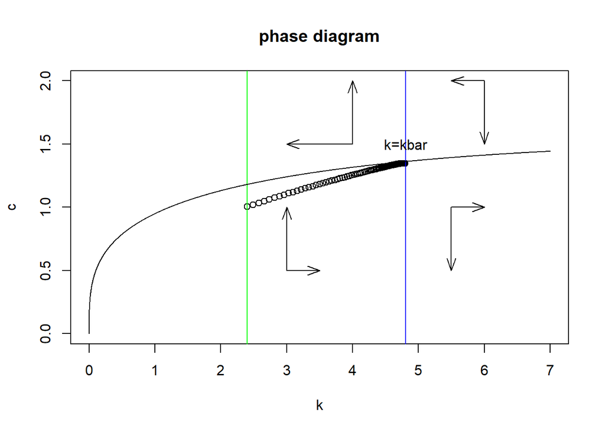

```r
##模拟路径
i=93
plot(k[1:i,j],c[1:i,j], xlim=c(0,7), ylim=c(0,2),main="phase diagram",xlab ="k", ylab ="c")
abline(v=kbar,col="blue") #在kbar处画出蓝色垂线
abline(v=kbar/2,col="green") #在kbar/2处画出绿色垂线
text(kbar,1.5,'k=kbar')
##c的增长路径
kxin=seq(0,7,by=0.001)
cxin=kxin^alpha-delta*kxin
lines(kxin,cxin)
##相位图
arrows(4,1.5,4,2,length = 0.15, angle = 20)
arrows(4,1.5,3,1.5,length = 0.15, angle = 20)
arrows(6,2,5.5,2,length = 0.15, angle = 20)
arrows(6,2,6,1.5,length = 0.15, angle = 20)
arrows(3,0.5, 3.5,0.5, length = 0.15, angle = 20)
arrows(3,0.5, 3,1, length = 0.15, angle = 20)
arrows(5.5,1, 5.5,0.5, length = 0.15, angle = 20)
arrows(5.5,1, 6,1, length = 0.15, angle = 20)
```